# A Study of Exercise Manner

Rong Xie

May 18, 2015

This study is about predicting the manner in which people did their exercise. In this study, we are using the Weight Lifting Exercise Dataset[1] , which consists of statistics from six young participants who were asked to perform one set of 10 repetitions of the Unilateral Dumbbell Biceps Curl in five different fashions: exactly according to the specification (Class A), throwing the elbows to the front (Class B), lifting the dumbbell only halfway (Class C), lowering the dumbbell only halfway (Class D) and throwing the hips to the front (Class E). The goal is to predict the classes through building a model on a large training set (http://groupware.les.inf.puc-rio.br/har).

## Loading and Cleaning Data

```r
training <- read.csv("/Users/rxie/pml-training.csv", na.strings=c("NA",""))
testing <- read.csv("/Users/rxie/pml-testing.csv", na.strings=c("NA",""))
dim(training)
```

```
## [1] 19622   160
```

```r
NAs <- apply(training,2,function(x) {sum(is.na(x))})
isNAs <- apply(training,2,function(x) {sum(is.na(x) > 0)})
length(NAs[isNAs])
```

```
## [1] 100
```

```r
training <- training[, !isNAs]
testing <- testing[, !isNAs]
dim(training)
```

```
## [1] 19622    60
```

## Model Training and Prediction

### Feature Selection

After loading and cleaning data, we have 60 fields in both training and testing datasets, 59 of which are potential features, and 1 is the class we need to predict. In order to training a better model, we further eliminate fields that are seemingly not related to our final prediction, such as names, time, and new_windows, etc. Specifically, fields 1 to 8 will be excluded from our datasets.

```r
rIndexes <- as.integer(c(1, 2, 3, 4, 5, 6, 7, 8))
trainingSet <- training[, -rIndexes]
testingSet <- testing[, -rIndexes]
classe <- trainingSet$classe
trainingSet <- trainingSet[, sapply(trainingSet, is.numeric)]
testingSet <- testingSet[, sapply(testingSet, is.numeric)]
trainingSet$classe <- classe
```

### Data Slicing

Then, the trainingSet is splitted into a pure training data set (70%) and a validation data set (30%). Note that the validation data set will be used to conduct cross validation in the future phases.

```r
library(caret)
set.seed(1989)
inTrain <- createDataPartition(y=trainingSet$classe, p=0.70, list=FALSE)
trainData <- trainingSet[inTrain,]
testData <- trainingSet[-inTrain,]
```

### Model Training

The random forest algorithm is applied to build our predictive model, since it has good performance in prediction accuracy. The 5-fold cross validation is used when we building the model. The figure below shows how importance each feature is to our prediction.

```r
controlRF <- trainControl(method="cv", 5)
modelRF <- train(classe ~., data=trainData, method="rf", trControl=controlRF, ntree=250)
modelRF
```

```
## Random Forest
##
## 13737 samples
##    51 predictor
##     5 classes: 'A', 'B', 'C', 'D', 'E'
##
## No pre-processing
## Resampling: Cross-Validated (5 fold)
##
## Summary of sample sizes: 10990, 10990, 10989, 10990, 10989
##
## Resampling results across tuning parameters:
##
##   mtry  Accuracy   Kappa      Accuracy SD  Kappa SD
##    2    0.9894447  0.9866460  0.001543231  0.001952300
##   26    0.9896630  0.9869227  0.001513519  0.001915563
##   51    0.9867510  0.9832382  0.003420845  0.004328788
##
## Accuracy was used to select the optimal model using  the largest value.
## The final value used for the model was mtry = 26.
```

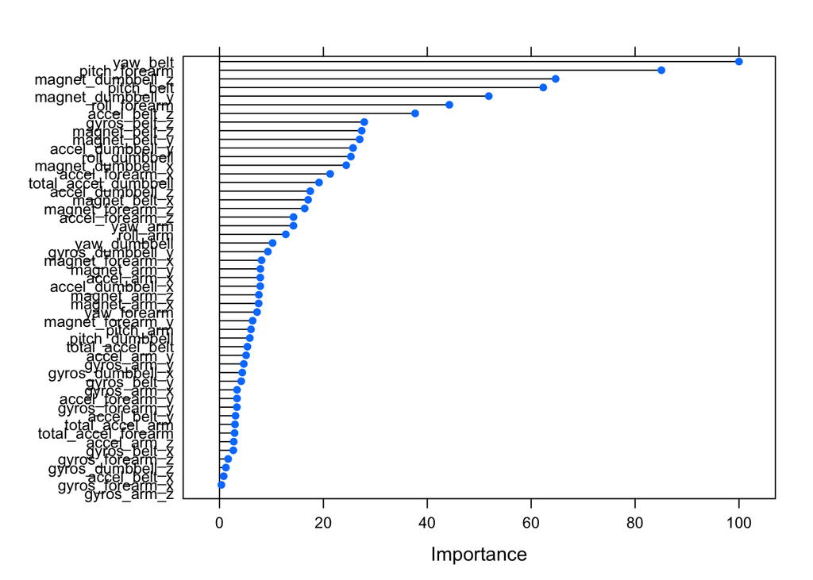

```r
plot(varImp(modelRF))
```

### Prediction and Evaluation

The predictive model is applied to the validation set. From the statistics we have below, it is expected to have approximated 99.22% accuracy and about 0.78% of out-of-sample error if we applied this model to the actual testing dataset.

```r
predictRF <- predict(modelRF, testData)
confusionMatrix(testData$classe, predictRF)
```

```
## Confusion Matrix and Statistics
##
##           Reference
## Prediction    A    B    C    D    E
##          A 1672    2    0    0    0
##          B   12 1126    0    1    0
##          C    0    5 1020    1    0
##          D    0    0   15  947    2
##          E    0    3    1    4 1074
##
## Overall Statistics
##
##                Accuracy : 0.9922
##                  95% CI : (0.9896, 0.9943)
##     No Information Rate : 0.2862
##     P-Value [Acc > NIR] : < 2.2e-16
##
##                   Kappa : 0.9901
##  Mcnemar's Test P-Value : NA
##
## Statistics by Class:
##
##                      Class: A Class: B Class: C Class: D Class: E
## Sensitivity            0.9929   0.9912   0.9846   0.9937   0.9981
## Specificity            0.9995   0.9973   0.9988   0.9966   0.9983
## Pos Pred Value         0.9988   0.9886   0.9942   0.9824   0.9926
## Neg Pred Value         0.9972   0.9979   0.9967   0.9988   0.9996
## Prevalence             0.2862   0.1930   0.1760   0.1619   0.1828
## Detection Rate         0.2841   0.1913   0.1733   0.1609   0.1825
## Detection Prevalence   0.2845   0.1935   0.1743   0.1638   0.1839
## Balanced Accuracy      0.9962   0.9942   0.9917   0.9951   0.9982
```

```r
accuracy <- postResample(predictRF, testData$classe)
accuracy
```

```
##  Accuracy     Kappa
## 0.9921835 0.9901108
```

```r
err <- 1 - as.numeric(confusionMatrix(testData$classe, predictRF)$overall[1])
err
```

```
## [1] 0.007816483
```

```r
result <- predict(modelRF, testingSet[, -length(names(testingSet))])
result
```

```
##  [1] B A B A A E D B A A B C B A E E A B B B
## Levels: A B C D E
```

Reference [1] Velloso, E.; Bulling, A.; Gellersen, H.; Ugulino, W.; Fuks, H. Qualitative Activity Recognition of Weight Lifting Exercises. Proceedings of 4th International Conference in Cooperation with SIGCHI (Augmented Human ’13) . Stuttgart, Germany: ACM SIGCHI, 2013.